# Tarea 9

Ita Santiago

```r
library(tidyverse)
```

**Máxima verosimilitud**

# Ejercicio 1

(Chihara, cap 6) En un comedor se recolectaron datos (en cierto horario predifinido) acerca del tiempo de espera de los clientes para que fueran atendidos Las mediciones son en minutos, y se midieron 174 clientes

```r
servicio <- read_csv("Service.csv")
servicio <- servicio %>% rename(id = ID, tiempo = Times)
```

Haz un histograma de los tiempos de servicio

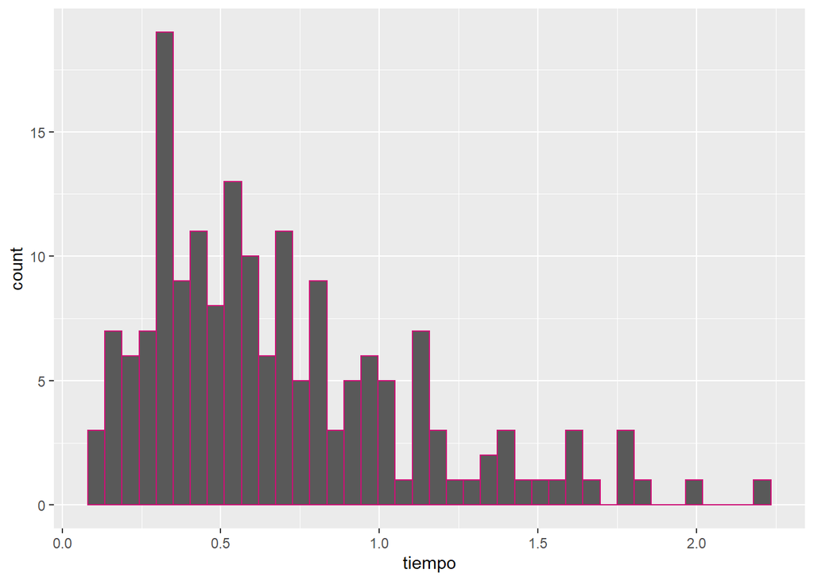

```r
ggplot(servicio,aes(tiempo))+geom_histogram(bins = 40,color="deeppink3")
```

Ajusta un modelo exponencial. Estima el parámetro lambda por máxima verosimilitud y calcula la media de tiempo de espera en minutos *tip: puedes usar MASS::fitdistr*

```r
f_estim<-MASS::fitdistr(servicio$tiempo,"exponential")
lambda<-f_estim$estimate
lambda
```

```
##     rate
## 1.439008
```

# Ejercicio 2

Checa el ajuste del modelo exponencial ¿el ajuste es razonable?

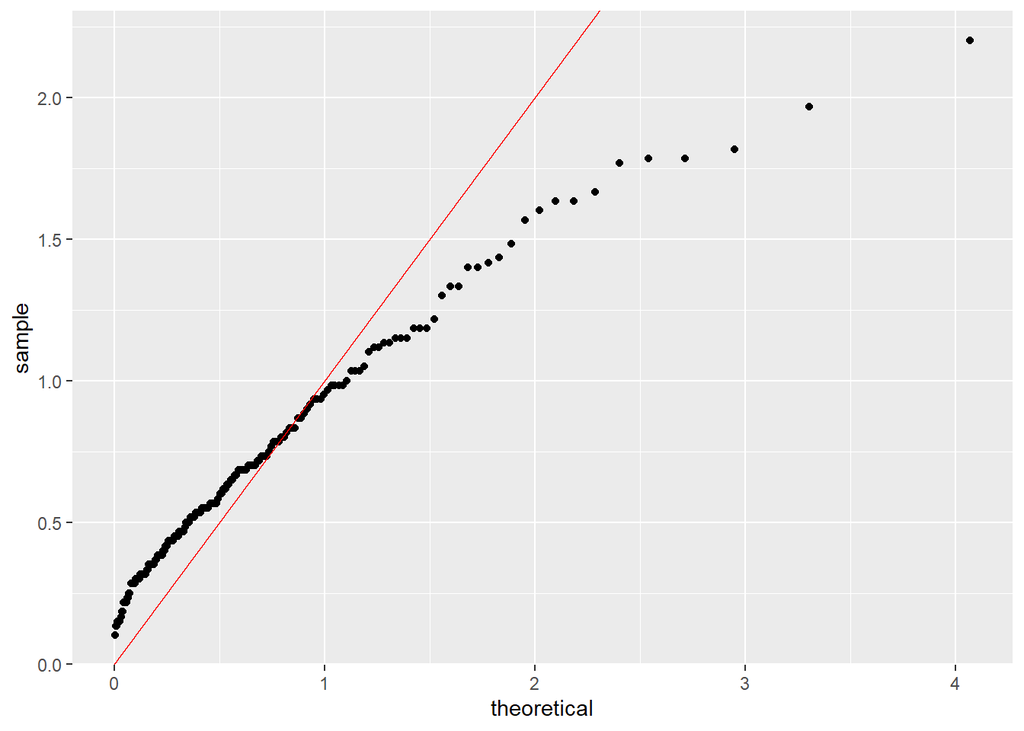

```r
ggplot(servicio, aes(sample = tiempo)) +
  geom_qq(distribution = stats::qexp,
          dparams = list(rate = lambda )) +
  geom_abline(colour = "red")
```

¿Cómo es el desajuste? No es muy bueno # Ejercicio 3 Ajusta una distribución gamma a estos datos usando máxima verosimlitud

```r
f_estim_gam<-MASS::fitdistr(servicio$tiempo,"gamma")
lambda_gam<-f_estim_gam$estimate
```

#¿Cuáles son tus estimadores de máxima verosimilitud=

```r
lambda_gam
```

```
##    shape     rate
## 2.813062 4.048018
```

# Ejercicio 4

Checa el ajuste del modelo gamma ¿el ajuste es razonable?

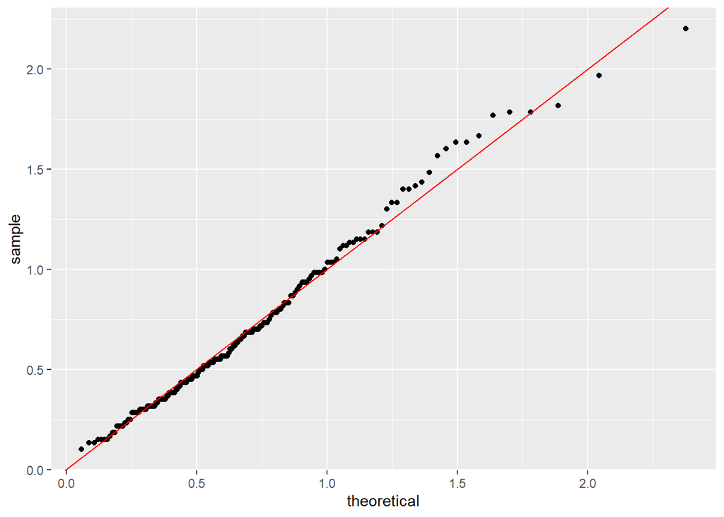

```r
ggplot(servicio, aes(sample = tiempo)) +
  geom_qq(distribution = stats::qgamma,
          dparams = list(rate = lambda_gam["rate"],
                         shape= lambda_gam["shape"])) +
  geom_abline(colour = "red")
```

¿Cómo se ve el ajuste en este caso? Es mejor que el de la exponencial

# Ejercicio 5

Haz una prueba visual para confirmar que la variación que es consistente con los datos que la variación que observamos en la gráfica anterior se debe a variación muestral.

```r
library(nullabor)
set.seed(654)
servicio_lineup <- lineup(null_dist("tiempo", dist = "gamma"), servicio,n=20)
```

```
## decrypt("Iw5d XVqV Hz k2AHqH2z 99")
```

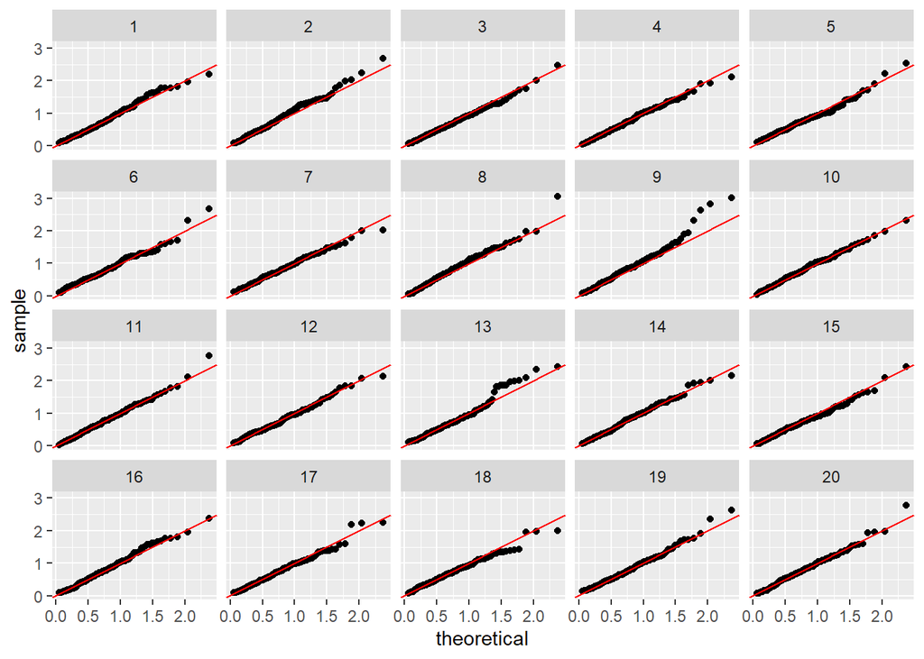

```r
# aquí tu gráfica
ggplot(servicio_lineup, aes(sample = tiempo)) +
  geom_qq(distribution = stats::qgamma,
          dparams = list(rate = lambda_gam["rate"],
                         shape= lambda_gam["shape"])) +
  geom_abline(colour = "red") + facet_wrap(~.sample,nrow = 4)
```

# Ejericio 6

Haz una gráfica del histograma con la densidad estimada sobrepuesta

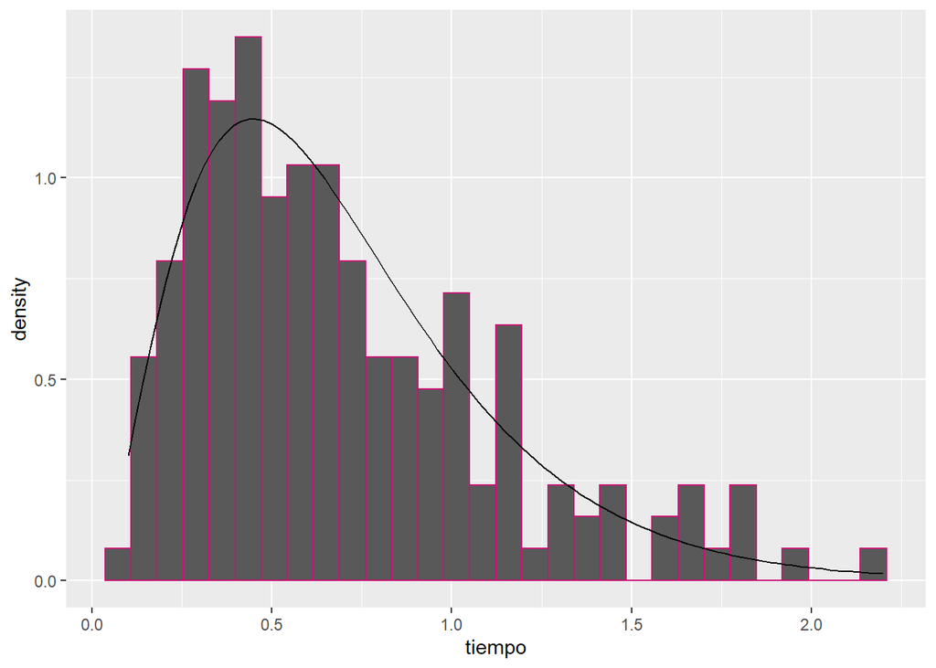

```r
g_shape<-f_estim_gam[["estimate"]][["shape"]]
g_scale<-1/f_estim_gam[["estimate"]][["rate"]]
ggplot(servicio,aes(tiempo)) +
  geom_histogram(aes(y = ..density..),color="deeppink3") +
  stat_function(fun=dgamma,args=list(shape=g_shape,                            scale=g_scale))
```

Los tiempos de servicio se distribuyen de manera muy similar a una distribución gamma.

# Bootstrap paramétrico

El coeficiente de variación (o desviación estándar relativa) se define como cv = sigma/mu El estimador de máxima verosimilitud del coeficiente de variación es el cociente de los estimadores de máxima verosimilitud de la desviación estándar y la media

1. Copia el código de clase para simular datos de una normal y estimar con máxima verosimilitud la desviación estándar y la media.

```r
set.seed(41852)
muestra <- rnorm(150, mean = 1, sd = 2)
crear_log_p <- function(x){
  log_p <- function(pars){
    media = pars[1]
    desv_est = pars[2]
    # ve la ecuación del ejercicio anterior
    z <- (x - media) / desv_est
    log_verosim <- -(log(desv_est) +  0.5 * mean(z^2))
    log_verosim
  }
  log_p
}
log_p <- crear_log_p(muestra)
```

2. Calcula el estimador de máxima verosimilitud del coeficiente de variación

```r
res <- optim(c(0, 0.5), log_p, control = list(fnscale = -1, maxit = 1000), method = "Nelder-Mead")
res$convergence
```

```
## [1] 0
```

```r
est_mv <- tibble(parametro = c("media", "sigma"), estimador = res$par) %>%
  column_to_rownames(var = "parametro")
est_mv
```

|  | estimador |
| --- | --- |
| media | 1.136001 |
| sigma | 1.838421 |

```r
(coef_var=est_mv[2,1]/est_mv[1,1])
```

```
## [1] 1.618326
```

3. Copia el código de clase para calcular el error estándar de bootstrap paramétrico para la media y la desviación estándar.

```r
simular_modelo <- function(n, media, sigma){
  rnorm(n, media, sigma)
}
muestra_bootstrap <- simular_modelo(length(muestra),
                                    est_mv["media", "estimador"],
                                    est_mv["sigma", "estimador"])
head(muestra_bootstrap)
```

```
## [1]  1.8583885  2.2084326  2.5852895  2.5174462 -0.7428032  0.5995989
```

```r
# creamos nueva verosimilitud para muestra bootstrap
log_p_boot <- crear_log_p(muestra_bootstrap)
# optimizamos
res_boot <- optim(c(0, 0.5), log_p_boot,
  control = list(fnscale = -1, maxit = 1000), method = "Nelder-Mead")
res_boot$convergence
```

```
## [1] 0
```

```r
est_mv_boot <- tibble(parametro = c("media", "sigma"), estimador = res_boot$par) %>%
  column_to_rownames(var = "parametro")
est_mv_boot
```

|  | estimador |
| --- | --- |
| media | 1.235914 |
| sigma | 1.710042 |

```r
rep_boot <- function(rep, crear_log_p, est_mv, n){
  muestra_bootstrap <- simular_modelo(length(muestra),
                               est_mv["media", "estimador"],
                               est_mv["sigma", "estimador"])
  log_p_boot <- crear_log_p(muestra_bootstrap)
  # optimizamos
  res_boot <- optim(c(0, 0.5), log_p_boot,
    control = list(fnscale = -1, maxit = 1000), method = "Nelder-Mead")
  try(if(res_boot$convergence != 0) stop("No se alcanzó convergencia."))
  tibble(parametro = c("media", "sigma"), estimador_boot = res_boot$par)
}
reps_boot <- map_dfr(1:5000, ~ rep_boot(.x, crear_log_p, est_mv,
                                        n = length(muestra)), rep = ".id")
reps_boot
```

| parametro | estimador_boot |
| --- | --- |
| media | 0.7970654 |
| sigma | 1.8999243 |
| media | 1.2321351 |
| sigma | 1.9641550 |
| media | 1.1407777 |
| sigma | 1.8895879 |
| media | 1.3270541 |
| sigma | 1.7290037 |
| media | 1.1928994 |
| sigma | 1.7284027 |

[output cut: 9990 more lines]

```r
error_est <- reps_boot %>% group_by(parametro) %>%
  summarise(ee_boot = sd(estimador_boot))
error_est
```

| parametro | ee_boot |
| --- | --- |
| media | 0.1503181 |
| sigma | 0.1061544 |

4. Modifica para que en cada muestra bootstrap calcules también el coeficiente de variación
5. Reporta el error estándar de las 3 cantidades

```r
set.seed(41852)
muestra <- rnorm(150, mean = 1, sd = 2)
crear_log_p_2 <- function(x){
  log_p_2 <- function(pars){
    media = pars[1]
    desv_est = pars[2]
    cf <- desv_est/media
    # ve la ecuación del ejercicio anterior
    z <- (x - media) / desv_est
    log_verosim <- -(log(desv_est) +  0.5 * mean(z^2))
    log_verosim
  }
  log_p_2
}
log_p_2 <- crear_log_p_2(muestra)

res_2 <- optim(c(0, 0.5,2), log_p_2, control = list(fnscale = -1, maxit = 1000), method = "Nelder-Mead")
res_2$convergence
```

```
## [1] 0
```

```r
est_mv_2 <- tibble(parametro = c("media", "sigma","cf"), estimador = res_2$par) %>%
  column_to_rownames(var = "parametro")
est_mv_2
```

|  | estimador |
| --- | --- |
| media | 1.1368257 |
| sigma | 1.8394055 |
| cf | 0.7364656 |

```r
simular_modelo_2 <- function(n, media, sigma){
  rnorm(n, media, sigma)
}
muestra_bootstrap_2 <- simular_modelo_2(length(muestra),
                                    est_mv_2["media", "estimador"],
                                    est_mv_2["sigma", "estimador"])
head(muestra_bootstrap_2)
```

```
## [1]  1.8595999  2.2098315  2.5868904  2.5190107 -0.7429854  0.6001359
```

```r
# creamos nueva verosimilitud para muestra bootstrap
log_p_boot_2 <- crear_log_p_2(muestra_bootstrap_2)
# optimizamos
res_boot_2 <- optim(c(0, 0.5,2), log_p_boot_2,
  control = list(fnscale = -1, maxit = 1000), method = "Nelder-Mead")
res_boot_2$convergence
```

```
## [1] 0
```

```r
est_mv_boot_2 <- tibble(parametro = c("media", "sigma","cf"), estimador = res_boot_2$par) %>%
  column_to_rownames(var = "parametro")
est_mv_boot_2
```

|  | estimador |
| --- | --- |
| media | 1.2371139 |
| sigma | 1.7104687 |
| cf | 0.7172509 |

```r
rep_boot_2 <- function(rep_2, crear_log_p_2, est_mv_2, n){
  muestra_bootstrap_2 <- simular_modelo_2(length(muestra),
                               est_mv_2["media", "estimador"],
                               est_mv_2["sigma", "estimador"])
  log_p_boot_2 <- crear_log_p_2(muestra_bootstrap_2)
  # optimizamos
  res_boot_2 <- optim(c(0, 0.5,2), log_p_boot_2,
    control = list(fnscale = -1, maxit = 1000), method = "Nelder-Mead")
  try(if(res_boot_2$convergence != 0) stop("No se alcanzó convergencia."))
  tibble(parametro = c("media", "sigma","cf"), estimador_boot_2 = res_boot_2$par)
}
reps_boot_2 <- map_dfr(1:5000, ~ rep_boot_2(.x, crear_log_p_2, est_mv_2,
                                        n = length(muestra)), rep_2 = ".id")
reps_boot_2
```

| parametro | estimador_boot_2 |
| --- | --- |
| media | 0.79738221 |
| sigma | 1.90011949 |
| cf | 0.85854579 |
| media | 1.23388289 |
| sigma | 1.96532570 |
| cf | 0.40886858 |
| media | 1.14153045 |
| sigma | 1.89121339 |
| cf | 0.71094337 |
| media | 1.32794529 |

[output cut: 9990 more lines]

```r
error_est_2 <- reps_boot_2 %>% group_by(parametro) %>%
  summarise(ee_boot_2 = sd(estimador_boot_2))
error_est_2
```

| parametro | ee_boot_2 |
| --- | --- |
| cf | 0.2122734 |
| media | 0.1504071 |
| sigma | 0.1062275 |